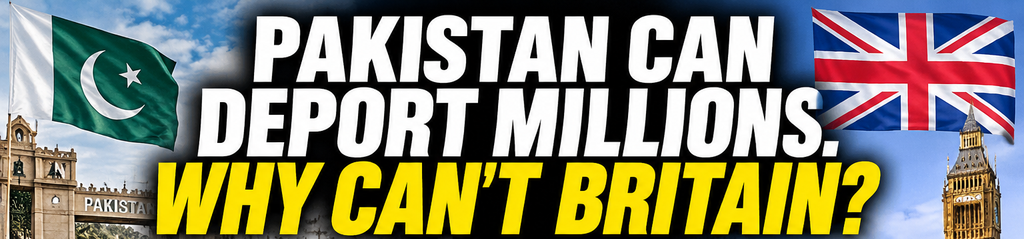

Immigration & Politics · 11 November 2026

# Pakistan Pushed Out 2.7 Million. Britain Can't Send Back One Rochdale Rapist.

Pakistan has driven 2.74 million Afghans back over its border in three years. Britain removed 445 failed Pakistani asylum seekers last year, cannot return a convicted child-rape gang leader, and signed off £153 million in aid to Pakistan anyway.

**2,744,068**Afghans returned from Pakistan, 15 Sept 2023 – 17 Oct 2026 (UNHCR–IOM)

**445**Pakistanis removed from Britain in 2025, against 10,853 refused asylum claims (Home Office)

**£153m**UK aid to Pakistan signed off over three years while Islamabad refuses Shabir Ahmed

## Two countries, two answers

When Pakistan decided it wanted illegal migrants gone, it got them gone. The UN's own monitors, UNHCR and the International Organization for Migration, record that [2,744,068 Afghans left Pakistan between 15 September 2023 and 17 October 2026](https://pakistan.iom.int/sites/g/files/tmzbdl1121/files/documents/2026-10/unhcr-iom-flash-update-116-v5.pdf). Of those, 278,758 were formally deported. Most of the rest went because staying meant arrest: in the latest UN reporting week, fear of arrest was the main reason given by undocumented returnees.

Pakistan did this under UN criticism, human-rights reports and international hand-wringing. It carried on regardless. Its relationship with Britain did not suffer for a single day.

Now look at Britain. In 2025 the Home Office [refused 10,853 asylum claims from Pakistani nationals and removed just 445 people to Pakistan](https://www.dawn.com/news/1979336). That is one in twenty-five. Pakistanis are now the largest single nationality claiming asylum in the UK.

Pakistan removes millions. Britain cannot manage five hundred.

## The Rochdale rapist Pakistan won't take

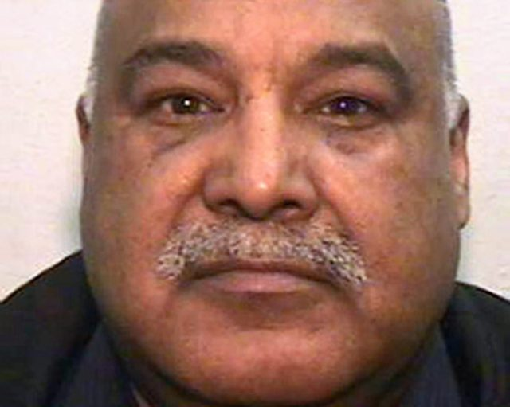

Shabir Ahmed. Photograph: Greater Manchester Police. [Original report](https://www.theguardian.com/law/2026/jul/03/freed-rochdale-grooming-gang-leader-was-judged-high-risk-to-children-in-2023).

Shabir Ahmed led the Rochdale grooming gang. He was jailed for 22 years in 2012 for 30 child rape offences against girls as young as 13. In July 2026 he walked free after serving 14 years. A 2023 Parole Board assessment had [judged him a very high risk of serious harm to children](https://www.theguardian.com/law/2026/jul/03/freed-rochdale-grooming-gang-leader-was-judged-high-risk-to-children-in-2023).

Britain stripped him of his citizenship. He was born in Pakistan. He should be on a plane. He isn't.

Pakistan's Foreign Office says Ahmed is ["entirely an internal matter of the United Kingdom"](https://www.arabnews.pk/node/2651129). Its spokesman told the world that Britain was where Ahmed grew up and was groomed and spoiled. Ahmed claims he renounced his Pakistani nationality; British officials dispute that he ever legally did.

Then came the threat. Islamabad warned that relations ["could be affected in all areas"](https://www.geo.tv/latest/678056-pakistan-may-halt-migrant-returns-if-uk-forces-rochdale-rapist-return) if Ahmed was forced on Pakistan, and that it may halt migrant returns altogether. A country that pushed 2.7 million people over its own border is lecturing Britain that removals "cannot be one-way traffic".

And at home, British law ties Britain's own hands. Section 7 of the Immigration Act 1971 protects Commonwealth citizens who settled here before 1973 from removal. It has [blocked Ahmed's deportation](https://www.geo.tv/latest/673366-uk-hints-at-visa-restrictions-as-pakistan-rejects-responsibility-for-rochdale-rapist) even after his citizenship was taken away. Fifty-five years on, nobody in Westminster had fixed it.

## Labour signs the cheque anyway

While Pakistan was refusing to take Ahmed back, Labour approved [a £153 million aid package for Pakistan](https://britbrief.co.uk/politics/partisanship/labour-pakistan-aid-row-over-shabir-ahmed-deportation.html) over three years. Downing Street's defence was that the money goes through charities and other organisations, not straight to the Pakistani government.

That misses the point entirely. Aid is leverage. Visas are leverage. A government serious about removals uses both. Labour handed over the money first and hoped for co-operation later. Pakistan pocketed the goodwill and kept saying no.

## The visas keep flowing

The Home Office issued [138,747 entry-clearance visas to Pakistani nationals in the year to March 2026](https://www.express.co.uk/news/politics/2240325/Pakistan-grooming-gangs-Shabir-Ahmed-visas-Zia-Yusuf), including 88,553 visitor visas. Pakistan values access to Britain enormously. That is exactly why access to Britain is the strongest card Britain holds. Labour won't play it.

## This is not new

Pakistan has form. In 2020 it [refused a charter flight carrying nearly three dozen deportees from the UK](https://www.thenews.com.pk/latest/739454-pakistan-refused-to-accept-flight-carrying-nearly-three-dozen-deportees-from-uk). In September 2021 the Home Office [cancelled its third deportation flight to Pakistan in a matter of months](https://www.theguardian.com/uk-news/2021/sep/09/home-office-cancels-third-deportation-flight-to-pakistan-in-recent-months). Governments of both colours have watched this happen and kept the aid and visas coming.

It is getting worse, not better. Home Office figures show Britain deported [just 63 Pakistani criminals last year, down from 263 in 2012](https://www.express.co.uk/news/politics/2240325/Pakistan-grooming-gangs-Shabir-Ahmed-visas-Zia-Yusuf). In 2021 the number fell to 18. Islamabad still describes its co-operation as "gold standard".

## Reform's answer: no returns, no visas

Reform UK is the only party with a written plan that treats this as the leverage problem it is. Its [Ending the Asylum Scam](https://britishlionsroar.github.io/ending-the-asylum-scam.html) policy commits a Reform government to visa bans on countries that refuse to take back their nationals, and names Pakistan, Somalia, Eritrea, Syria, Afghanistan and Sudan. Countries without large visa interests in Britain would face tariffs instead.

Its [Operation Restoring Justice](https://britishlionsroar.github.io/operation-restoring-justice.html) plan creates a UK Deportation Command to identify, detain and remove illegal migrants, with lifetime re-entry bans for everyone deported. Reform would also leave the European Convention on Human Rights and repeal the Human Rights Act, removing the legal obstacle course that keeps people like Ahmed here.

When Islamabad threatened to stop taking returns, Zia Yusuf, Reform's home affairs spokesman, called it what it is. Pakistanis are "not being deported, so this 'threat' is laughable," he [told the Daily Express](https://www.express.co.uk/news/politics/2240325/Pakistan-grooming-gangs-Shabir-Ahmed-visas-Zia-Yusuf):

> "As Home Secretary I will ensure Pakistan takes back the Rochdale Monster Shabir Ahmed, and all its illegal migrants. If they don't, I will place a blanket ban on visas for Pakistani nationals, sanction members of their government and freeze their assets in Britain."

All of Reform's published policy documents are kept in full in the [British Lions Roar Reform UK Policy & Document Library](https://britishlionsroar.github.io/reform-uk-policy-document-library.html).

## The question Labour can't answer

> Pakistan removed 2.7 million people and paid no price with Britain. Britain removed 445 and paid £153 million for the privilege. Which country is taken seriously?

Pakistan understands leverage. It uses arrests to clear its country, and threats to protect its interests abroad. Britain has more leverage over Pakistan than Pakistan has over Britain: aid, visas and access to the British economy. Labour gives all three away for nothing.

No returns, no visas, no aid. Until a government says that and means it, Shabir Ahmed stays in Britain, and so do the thousands behind him.

[figure not shown]

**Follow The British Lions Roar on Substack**  
Scan the code or visit [thebritishlionsroar.substack.com](https://thebritishlionsroar.substack.com/)

## Want to Dive Deeper? Official sources you can link:

- UNHCR–IOM Flash Update #116, Afghan returns from Pakistan, 15 Sept 2023 – 17 Oct 2026:  
  https://pakistan.iom.int/sites/g/files/tmzbdl1121/files/documents/2026-10/unhcr-iom-flash-update-116-v5.pdf
- Dawn — Pakistan comes under scrutiny as UK cracks down on asylum abuse (10,853 refused, 445 removed):  
  https://www.dawn.com/news/1979336
- The Guardian — Freed Rochdale grooming gang leader was judged high risk to children in 2023:  
  https://www.theguardian.com/law/2026/jul/03/freed-rochdale-grooming-gang-leader-was-judged-high-risk-to-children-in-2023
- Arab News — Islamabad opposes UK push to deport freed grooming gang leader:  
  https://www.arabnews.pk/node/2651129
- Geo News — Pakistan may halt migrant returns if UK forces deportation of Rochdale rapist:  
  https://www.geo.tv/latest/678056-pakistan-may-halt-migrant-returns-if-uk-forces-rochdale-rapist-return
- Geo News — Section 7 of the Immigration Act 1971 and the Ahmed case:  
  https://www.geo.tv/latest/673366-uk-hints-at-visa-restrictions-as-pakistan-rejects-responsibility-for-rochdale-rapist
- BritBrief — Labour's £153m Pakistan aid and the Shabir Ahmed row:  
  https://britbrief.co.uk/politics/partisanship/labour-pakistan-aid-row-over-shabir-ahmed-deportation.html
- Daily Express — Zia Yusuf's "blanket ban" threat; 138,747 visas; 63 Pakistani criminals deported:  
  https://www.express.co.uk/news/politics/2240325/Pakistan-grooming-gangs-Shabir-Ahmed-visas-Zia-Yusuf
- The News — Pakistan refused flight carrying deportees from UK (2020):  
  https://www.thenews.com.pk/latest/739454-pakistan-refused-to-accept-flight-carrying-nearly-three-dozen-deportees-from-uk
- The Guardian — Home Office cancels third deportation flight to Pakistan (2021):  
  https://www.theguardian.com/uk-news/2021/sep/09/home-office-cancels-third-deportation-flight-to-pakistan-in-recent-months
- Reform UK — Ending the Asylum Scam:  
  https://britishlionsroar.github.io/ending-the-asylum-scam.html
- Reform UK — Operation Restoring Justice:  
  https://britishlionsroar.github.io/operation-restoring-justice.html
- Reform UK Policy & Document Library:  
  https://britishlionsroar.github.io/reform-uk-policy-document-library.html

**Editorial approach:** This article is written in plain English, following George Orwell's rule: if you can say something simply, do so. It combines investigative reporting with policy analysis and opinion. Satire is used where appropriate to test ideas by applying them consistently. Facts are sourced; opinions are labelled; institutions are not indulged.

**DISCLAIMER:** Factual statements in this article are supported by cited sources. Analysis and interpretation are clearly presented as opinion. Nothing published here is intended to incite violence, harassment, or hatred, nor to cause harm. Disagreement with arguments or conclusions does not constitute harm or violence. Where Islamic doctrine or immigration/demographics are discussed, focus is policy and aggregate outcomes — not individuals by race, ethnicity or religion.